# Guitar Tablature Creative Encoding Project

Author

Hannah Govert

Published

December 19, 2025

```
Music 255:  Encoding Music
Guitar Tablature Creative Encoding Project
Hannah Govert
December 19, 2025
```

# 0. Import Statements

`pip install --upgrade metpy` required to import xarray package.

```python
# import libraries
import pandas as pd
import os
import bs4
from bs4 import BeautifulSoup
from lxml import etree # lxml is imported for xpath examples

from pathlib import Path
import requests
import plotly.express as px
import plotly.graph_objects as go
from collections import Counter
import math
import numpy as np

# Visualisation dependencies
import matplotlib.pyplot as plt
import textwrap
import networkx as nx
from pyvis.network import Network
import seaborn as sns

import warnings
warnings.filterwarnings('ignore')

import uuid
import glob

from datetime import datetime
import chardet
import random

import subprocess

import xarray as xr

import altair as alt

# setup plotting for quarto
alt.renderers.enable('default')
import plotly.io as pio
pio.renderers.default = "plotly_mimetype+notebook_connected"
```

# 1. Motivation

I have been playing guitar for more than 15 years, initially being taught classically. Once I stopped receiving lessons, it became easier to learn new songs through guitar tablature, as it plainly indicates which string to pluck and fret to press at any given moment.

The article *Tablature* by Thurston Dart and revised by John Morehen and Richard Rastall details the general history of tablature. Tablature systems have been used as early as the 14th century in western European music, displaying the playing technique for various instruments. These notational systems use letters, numbers, and other symbols not found in traditional staff notation. Early guitar tablature throughout the 16th through 18th century was written using lute tablature styles that varied by region, notably Germany, France, Italy, and Spain.

The Music Encoding Initiative (MEI) is a “community-driven, open-source effort to define a system for encoding musical documents in a machine-readable structure” that allows musical pieces to be programmatically analyzed. In class, we worked with Common Music Notation MEI to analyze contrapuntal duos. This type of analysis was very intriguing to me, but I wanted to apply it to my personal experience with guitar and its tablature. MEI has a String Tablature module that was designed for plucked-string instruments like the lute and guitar.

While there exist some guitar-focused projects, such as *Robotaba Guitar Tablature Transcription Framework* from Gregory Burlet and Ichiro Fujinaga and *AnimeTAB: A New Guitar Tablature Dataset of Anime and Game Music* from Yuecheng Zhou, Yaolong Ju, and Lingyun Xie, much of the existing research using tablature MEI focuses on lute pieces. Consequently, there are many accessible lute tablature MEI files to analyze that can be found on online databases such as the Ricercar Data Lab. One place I was able to find guitar tablature MEI files was from the Tablature Interest Group repository.

Clearly, there is lots to explore with guitar tablature and MEI, but my primary point of inquiry was the following: **How does String Tablature MEI (specifically guitar tablature) compare to Common Music Notation MEI? What data and analysis can we gain from its specific structure, and conversely, what do we lose?** Additionally, I wanted to investigate the possible methods in which I could encode my own guitar tablature MEI files to address the lack of easily accessed or existing ones.

# 2. Implementation

The following is a roadmap of my implementation to explore and analyze the guitar tablature MEI files.

- 2.1 Importing Files
- 2.2 Visualizing MEI Structure as Networks
- 2.3 Functions to Build Heatmaps
- 2.4 Animations of Heatmaps
- 2.5 Creating My Own MEI File

## 2.1. Importing Files

Using the code provided in the BeautifulSoup tutorial, I imported MEI files to use. The guitar pieces were downloaded from Tablature Interest Group Repository and the lute piece was downloaded from the Ricercar Data Lab. Additionally, I was able to create a file using various softwares described in Section 2.5.

```python
# local files
file_list = sorted(glob.glob('mei/*'))

# here is the function that will return our tuple
def open_file(filename):
    with open(filename, 'rb') as file:
        # Detect the encoding
        result = chardet.detect(file.read())
        # Seek to the beginning of the file
        file.seek(0)
        # Decode the file using the detected encoding
        content = file.read().decode(result['encoding'])
        file_name = os.path.basename(filename)
        base_name, extension = os.path.splitext(file_name)
        file_name_for_dict_check = base_name + extension
        revised_name = base_name + "_rev" + extension
        soup = BeautifulSoup(content, 'xml')

        return soup, file_name_for_dict_check, revised_name
```

I updated the code to make a function that would return a dataframe of the information I wanted about each file (name, revised name, and soup object).

```python
# function to create soup file for each MEI file in file_list
def create_soup():
    soups = []
    filenames = []
    revs = []
    for i in range(0, len(file_list)):
        my_file = file_list[i]
        my_soup_with_names = open_file(my_file)

        # here are the tree items from our tuple

        # soup file itself
        soup = my_soup_with_names[0]

        # the full filename with extension
        filename = my_soup_with_names[1]

        # the full filename with extension, now with 'rev' as part of the basename
        revised_name = my_soup_with_names[2]

        soups.append(soup)
        filenames.append(filename)
        revs.append(revised_name)

        df = pd.DataFrame({'filename': filenames, 'revised name': revs, 'soup': soups})
    return df

soups = create_soup()
```

## 2.2 Visualizing MEI Structure as Networks

Before diving into visualizations and analysis, I wanted to explore the structure of the String Tablature MEI to better understand how it compared to Common Music Notation MEI.

### 2.2.1 Defining Functions

Using code from the BeautifulSoup tutorial, I defined functions for creating the networks.

```python
# functions
def format_element(tag: bs4.element.Tag, wrap_length=20, exclude=[]):
    attrs_list = []
    for a, v in tag.attrs.items():
        if a in exclude:
            continue
        attrs_list.append(f"{a}={v}")
    formatted_string = f"{tag.name} ({' '.join(attrs_list)})" if attrs_list else tag.name
    return textwrap.fill(formatted_string, wrap_length)

def create_network(tag: bs4.element.Tag, with_attributes: bool = False, attrs_to_exclude=[]):

    all_tags = [tag] + tag.find_all()
    G = nx.DiGraph()
    for node in all_tags:
        depth = len(list(node.parents))
        G.add_node(
                   id(node),
                   label=format_element(node, exclude=attrs_to_exclude) if with_attributes else node.name,
                   value=len(list(node.descendants)),
                   group=depth,
                   level=depth,
                   scaling={'label': {'enabled': True}},
                  )
    for node in all_tags:
        for child in node.children:
            if child.name:
                G.add_edge(id(node), id(child),
                           arrows='to',
                       id=f"{id(node)}_{node.name}|{id(child)}_{child.name}")

    return G

def display_network(network,
                    filename="tmp.html",
                    width=900,
                    height=900,
                    bgcolor="white",
                    font_color="black",
                    notebook=True,
                   ):

    nt = Network(notebook=notebook, width=width, height=height, bgcolor=bgcolor, font_color=font_color)
    nt.from_nx(network)

    return nt.show(filename)
```

Using the “Hot For Teacher” by Van Halen file from the Tablature Interest Group Repository, I created the following networks.

### 2.2.2 Head Elements

The first is a network of the head elements. These are quite similar to the ones found in Common Music Notation MEI.

```python
# get base filename of the mei file
basename = os.path.splitext(soups.iloc[5]['filename'])[0]


# here we find the first 'music' element, which in turn shows all the measures
measure_network = create_network(soups.iloc[5]['soup'].find('meiHead'))
display_network(measure_network, filename=f"{basename}.html")
```

[interactive chart not shown]

### 2.2.3 All Measures

This network is the music section of the file, showing all the measures of the piece.

```python
# get base filename of the mei file
basename = os.path.splitext(soups.iloc[5]['filename'])[0]


# here we find the first 'music' element, which in turn shows all the measures
measure_network = create_network(soups.iloc[5]['soup'].find('music'))
display_network(measure_network, filename=f"{basename}.html")
```

[interactive chart not shown]

### 2.2.4 Single Measure with Attributes

Lastly, we take a closer look at one of the measures, including its attributes. This is where we see the most notable differences between Common Music Notation and String Tablature. The measure element has more children than just staff, including slur, pitch inflection, and directive. Also, there is a tab group element that is a parent of the note elements. These notes have course, fret, and tie attributes instead of duration, octave, and pitchname. Additionally, there are no accidental elements in this part of the file, as those would be indicated in the tuning section.

```python
# name for network
basename = os.path.splitext(soups.iloc[5]['filename'])[0]

# selected measure
measure_to_display = 3

# show attributes of elements?
attributes = True
# make the network
measure_network_with_attrs = create_network(
    soups.iloc[5]['soup'].find("measure", {"n": measure_to_display}),
    with_attributes=attributes,
    attrs_to_exclude=["xml:id"]
)

# show it
display_network(measure_network_with_attrs, filename=f"{basename}_attributes.html")
```

[interactive chart not shown]

## 2.3 Functions to Build Heatmaps

### 2.3.1 Initial Function

Common Music Notation MEI lends itself to useful visualizations of note and pitch distributions as well as melodic and harmonic patterns using CRIM Intervals. When thinking about what String Tablature MEI can uniquely offer, I was drawn to the idea of showing where on a guitar neck notes are played. This led me to create heatmaps that reflected a guitar neck.

I developed functions to create heatmaps of entire pieces, allowing me to easily visualize the files I downloaded.

```python
# function for creating heatmap of entire piece (not for pieces with muted notes)
def full_build(soup):
    # counting strings and frets
    courses = [n.get('tab.course') for n in soup.find_all('note')]
    frets = [n.get('tab.fret') for n in soup.find_all('note')]

    # creating dataframe
    df = pd.DataFrame({'course': courses, 'fret': frets})

    # converting into integers
    df['course'] = df['course'].astype('int64')
    df['fret'] = df['fret'].astype('int64')

    # grouping by string
    grouped = df.groupby('course')
    grouped_df = grouped.value_counts().reset_index().sort_values('fret').sort_values('course')

    # initializing empty matrix
    rows, cols = 6, 13
    mat = np.zeros((rows, cols), dtype=int)


    # filling in matrix from dataframe
    for i in range(0,len(grouped_df)):
        r = grouped_df.iloc[i]['course']-1
        c = grouped_df.iloc[i]['fret']
        n = grouped_df.iloc[i]['count']
        mat[r,c] = n

    fig = px.imshow(mat, origin = 'lower',
               labels = dict(x = 'fret',
                             y = 'string',
                             color = 'count'),
               y = ['1','2','3','4','5','6'],
               x = ['0','1','2','3','4','5','6','7','8','9','10','11','12'])

    fig.update_layout(title = 'Guitar/Lute Heatmap')
    return fig
```

The following is a heatmap of “Hot for Teacher” by Van Halen. This file was downloaded from the Tablature Interest Group Repository. It is not the complete song, but rather a 3-measure snippet shown below.

[figure not shown]

“Hot For Teacher” by Van Halen

```python
# hot for teacher
full_build(soups.iloc[5]['soup']).update_layout(title = 'Guitar Neck Heatmap of "Hot for Teacher" by Van Halen')
```

[interactive chart not shown]

### 2.3.2 Including Muted Notes

When attempting to use the same function for “Panama” by Van Halen, I ran into a new issue. First, it used a ‘tab.string’ attribute instead of ‘tab.course’ in its structure. Second, the song included muted notes, indicated by an ‘X’. I replaced these with a -1 value so I could use the same strategy to build the heatmap.

```python
# function for creating heatmap of entire piece (for pieces with muted notes)
# this uses tab.string instead of tab.course because of the structure of the Panama MEI file
def full_build_mute(soup):
    # counting strings and frets
    strings = [n.get('tab.string') for n in soup.find_all('note')]
    frets = [n.get('tab.fret') for n in soup.find_all('note')]

    # converting into dataframe
    df = pd.DataFrame({'string': strings, 'fret': frets})

    # grouping by string
    grouped = df.groupby('string')
    grouped_df = grouped.value_counts().reset_index().sort_values('fret').sort_values('string')

    # replacing x with -1
    grouped_df['fret'] = grouped_df['fret'].str.replace('x', '-1')

    # converting values to integers
    grouped_df['string'] = grouped_df['string'].astype('int64')
    grouped_df['fret'] = grouped_df['fret'].astype('int64')

    # initalizing array
    rows, cols = 6, 14 # adding extra fret value
    mat = np.zeros((rows, cols), dtype=int)


    # filling in array from dataframe
    for i in range(0,len(grouped_df)):
        r = grouped_df.iloc[i]['string']-1
        c = grouped_df.iloc[i]['fret']+1 # since we're using -1
        n = grouped_df.iloc[i]['count']
        mat[r,c] = n

    fig = px.imshow(mat, origin = 'lower',
               labels = dict(x = 'fret',
                             y = 'string',
                             color = 'count'),
                y = ['1','2','3','4','5','6'],
               x = ['X','0','1','2','3','4','5','6','7','8','9','10','11','12'])
    fig.update_layout(title = 'Guitar/Lute Neck Heatmap (including muted notes)')
    return fig
```

```python
# panama
full_build_mute(soups.iloc[6]['soup']).update_layout(title = 'Guitar Neck Heatmap of "Panama" by Van Halen')
```

[interactive chart not shown]

### 2.3.3 Expanding Heatmap

he next problem I ran into was when I was creating a heatmap for “Ice” by Satriani. This piece had notes played farther up the neck, so I had to expand the matrix.

[figure not shown]

“Ice” by Satriani

```python
# function for creating heatmap of entire piece (not for pieces with muted notes)
def full_build_extra(soup):
    # counting strings and frets
    courses = [n.get('tab.course') for n in soup.find_all('note')]
    frets = [n.get('tab.fret') for n in soup.find_all('note')]

    # creating dataframe
    df = pd.DataFrame({'course': courses, 'fret': frets})

    # converting into integers
    df['course'] = df['course'].astype('int64')
    df['fret'] = df['fret'].astype('int64')

    # grouping by string
    grouped = df.groupby('course')
    grouped_df = grouped.value_counts().reset_index().sort_values('fret').sort_values('course')

    # initializing empty matrix
    rows, cols = 6, 20
    mat = np.zeros((rows, cols), dtype=int)


    # filling in matrix from dataframe
    for i in range(0,len(grouped_df)):
        r = grouped_df.iloc[i]['course']-1
        c = grouped_df.iloc[i]['fret']
        n = grouped_df.iloc[i]['count']
        mat[r,c] = n

    fig = px.imshow(mat, origin = 'lower',
               labels = dict(x = 'fret',
                             y = 'string',
                             color = 'count'),
               y = ['1','2','3','4','5','6'],
               x = ['0','1','2','3','4','5','6','7','8','9','10','11','12','13','14','15','16','17','18','19'])

    fig.update_layout(title = 'Guitar/Lute Heatmap')
    return fig
```

```python
full_build_extra(soups.iloc[3]['soup']).update_layout(title = 'Guitar Neck Heatmap of "Ice" by Satriani')
```

[interactive chart not shown]

The piece “Not of this Earth” by Satriani required the expanded heatmap as well. This does not line up with the file given, indicating possible errors in the MEI file code. Based off the notation, I would expect muted notes as well, but they don’t appear in the file.

[figure not shown]

“Not of This Earth” by Satriani

The following is a list of fret indications in the file.

```python
# frets
[n.get('tab.fret') for n in soups.iloc[4]['soup'].find_all('note')]
```

```
['12',
 '13',
 '16',
 '16',
 '19',
 '8',
 '9',
 '11',
 '9',
 '9',
 '7',
 '8',
 '10',
 '8',
 '8']
```

```python
full_build_extra(soups.iloc[4]['soup']).update_layout(title = 'Guitar Neck Heatmap of "Not of this Earth" by Satriani')
```

[interactive chart not shown]

## 2.4 Animations of Heatmaps

### 2.4.1 Initial Functions

To reveal patterns in the form of a piece, I went about animating heatmaps by measure. Similarly to the previous heatmaps, I needed to make different functions for “Panama” by Van Halen compared to the other pieces.

```python
# function to create matrix for each measure, returning list of matrices
def measure_builder(soup):

    # counting measures
    measures = soup.find_all('measure')

    # initializing matrix
    mlist = []
    for i in range(1, len(measures)+1):
        # counting elements, creating dataframe, grouping data
        measure = soup.find('measure', {'n': i})
        courses = [n.get('tab.course') for n in measure.find_all('note')]
        frets = [n.get('tab.fret') for n in measure.find_all('note')]
        df = pd.DataFrame({'course': courses, 'fret': frets})
        df['course'] = df['course'].astype('int64')
        df['fret'] = df['fret'].astype('int64')
        grouped = df.groupby('course')
        grouped_df = grouped.value_counts().reset_index().sort_values('fret').sort_values('course')

        # initializing empty matrix
        rows, cols = 6, 13
        mat = np.zeros((rows, cols), dtype=int)

        # filling in matrix from dataframe
        for i in range(0,len(grouped_df)):
            r = grouped_df.iloc[i]['course']-1
            c = grouped_df.iloc[i]['fret']
            n = grouped_df.iloc[i]['count']
            mat[r,c] = n

        # filling list
        mlist.append(mat)

    return mlist
```

```python
# function to create matrix for each measure, returning list of matrices
def measure_builder_mute(soup):
    # counting measures
    measures = soup.find_all('measure')

    # initializing matrix
    mlist = []
    for i in range(1, len(measures)+1):
        # counting elements, creating dataframe, grouping data
        measure = soup.find('measure', {'n': i})
        strings = [n.get('tab.string') for n in measure.find_all('note')]
        frets = [n.get('tab.fret') for n in measure.find_all('note')]
        df = pd.DataFrame({'string': strings, 'fret': frets})

        # grouping data
        grouped = df.groupby('string')
        grouped_df = grouped.value_counts().reset_index().sort_values('fret').sort_values('string')

        # replacing x with -1
        grouped_df['fret'] = grouped_df['fret'].str.replace('x', '-1')

        # converting values to integers
        grouped_df['string'] = grouped_df['string'].astype('int64')
        grouped_df['fret'] = grouped_df['fret'].astype('int64')

        # initializing empty matrix
        rows, cols = 6, 14
        mat = np.zeros((rows, cols), dtype=int)

        # filling in matrix from dataframe
        for i in range(0,len(grouped_df)):
            r = grouped_df.iloc[i]['string']-1
            c = grouped_df.iloc[i]['fret']+1
            n = grouped_df.iloc[i]['count']
            mat[r,c] = n

        # filling list
        mlist.append(mat)

    return mlist
```

```python
def animate_heatmap(soup, mute):
    # counting measures
    measures = soup.find_all('measure')

    # initializing list
    m_n = []

    # calling function to fill list
    for i in range(0, len(measures)):
        if mute == False:
            m = measure_builder(soup)[i]
        else:
            m = measure_builder_mute(soup)[i]
        m_n.append(m)

    # creating xarray for animation
    data = xr.DataArray(m_n, dims = ['measure', 'course', 'fret'])

    # creating heatmap
    if mute == False:
        fig = px.imshow(data, origin = 'lower', animation_frame = 'measure',
               labels = dict(x = 'fret',
                             y = 'string',
                             color = 'count'),
               y = ['1','2','3','4','5','6'],
               x = ['0','1','2','3','4','5','6','7','8','9','10','11','12'])
    # if file has mutes like Panama
    else:
        fig = px.imshow(data, origin = 'lower', animation_frame = 'measure',
               labels = dict(x = 'fret',
                             y = 'string',
                             color = 'count'),
               y = ['1','2','3','4','5','6'],
               x = ['X','0','1','2','3','4','5','6','7','8','9','10','11','12'])

    return fig
```

```python
animate_heatmap(soups.iloc[5]['soup'], False).update_layout(title = 'Guitar Neck Heatmap of "Hot for Teacher" by Van Halen Across Measures')
```

[interactive chart not shown]

The animated heatmap for “Panama” by Van Halen reveals some potential errors in the MEI file code. The PDF of the tab can be found [here](https://github.com/music-encoding/tablature-ig/blob/master/examples/guitar/van_halen-panama.pdf). There should be more than 18 measures. Additionally, the fifth measure (measure=4) shows multiple notes being played 10 plus times in the singular measure, including one being played 18 times. This is very unusual and does not line up with any of the measures in the piece.

While it was not my intent to reveal errors in the encoding of these pieces, the heatmaps prove to be useful to showcase where the file and tab don’t align.

```python
animate_heatmap(soups.iloc[6]['soup'], True).update_layout(title = 'Guitar Neck Heatmap of "Panama" by Van Halen Across Measures')
```

[interactive chart not shown]

### 2.4.2 Lute Exploration

Due to the errors in the Tablature Interest Group Repository files, I decided to look at the following lute piece.

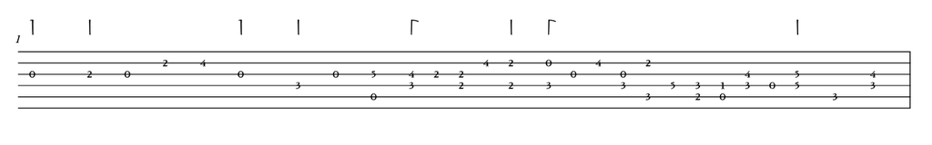

Looking at this lute piece, we see there is only one measure. Thus, animation by measure does not reveal much. What else can I animate by?

```python
animate_heatmap(soups.iloc[0]['soup'], False).update_layout(title = 'Lute Neck Heatmap of "Fantasia"')
```

[interactive chart not shown]

String Tablature MEI contains ‘tabGrp’ elements that refer to vertically-aligned symbols, i.e. chords. I can animate the heatmap by this element, seeing which notes are played at the same time.

```python
# function to create matrix for each tab group, returning list of matrices
def group_builder(soup):

    # counting measures
    tabgrps = soup.find_all('tabGrp')

    # initializing matrix
    tlist = []
    for i in range(0, len(tabgrps)):
        # counting elements, creating dataframe, grouping data
        tabgrp = soup.find_all('tabGrp')[i]
        courses = [n.get('tab.course') for n in tabgrp.find_all('note')]
        frets = [n.get('tab.fret') for n in tabgrp.find_all('note')]
        df = pd.DataFrame({'course': courses, 'fret': frets})
        df['course'] = df['course'].astype('int64')
        df['fret'] = df['fret'].astype('int64')
        grouped = df.groupby('course')
        grouped_df = grouped.value_counts().reset_index().sort_values('fret').sort_values('course')

        # initializing empty matrix
        rows, cols = 6, 13
        mat = np.zeros((rows, cols), dtype=int)

        # filling in matrix from dataframe
        for i in range(0,len(grouped_df)):
            r = grouped_df.iloc[i]['course']-1
            c = grouped_df.iloc[i]['fret']
            n = grouped_df.iloc[i]['count']
            mat[r,c] = n

        # filling list
        tlist.append(mat)

    return tlist
```

```python
# function to create matrix for each measure, returning list of matrices
def group_builder_mute(soup):
    # counting measures
    tabgrps = soup.find_all('tabGrp')

    # initializing matrix
    tlist = []
    for i in range(0, len(tabgrps)):
        # counting elements, creating dataframe, grouping data
        tabgrp = soup.find_all('tabGrp')[i]
        strings = [n.get('tab.string') for n in tabgrp.find_all('note')]
        frets = [n.get('tab.fret') for n in tabgrp.find_all('note')]
        df = pd.DataFrame({'string': strings, 'fret': frets})

        # grouping data
        grouped = df.groupby('string')
        grouped_df = grouped.value_counts().reset_index().sort_values('fret').sort_values('string')

        # replacing x with -1
        grouped_df['fret'] = grouped_df['fret'].str.replace('x', '-1')

        # converting values to integers
        grouped_df['string'] = grouped_df['string'].astype('int64')
        grouped_df['fret'] = grouped_df['fret'].astype('int64')

        # initializing empty matrix
        rows, cols = 6, 14
        mat = np.zeros((rows, cols), dtype=int)

        # filling in matrix from dataframe
        for i in range(0,len(grouped_df)):
            r = grouped_df.iloc[i]['string']-1
            c = grouped_df.iloc[i]['fret']+1
            n = grouped_df.iloc[i]['count']
            mat[r,c] = n

        # filling list
        tlist.append(mat)

    return tlist
```

```python
def animate_heatmap2(soup, mute):
    # counting measures
    tabgrps = soup.find_all('tabGrp')

    # initializing list
    t_n = []

    # calling function to fill list
    for i in range(0, len(tabgrps)):
        if mute == False:
            t = group_builder(soup)[i]
        else:
            t = group_builder_mute(soup)[i]
        t_n.append(t)

    # creating xarray for animation
    data = xr.DataArray(t_n, dims = ['group', 'course', 'fret'])

    if mute == False:
        fig = px.imshow(data, origin = 'lower', animation_frame = 'group',
               labels = dict(x = 'fret',
                             y = 'string',
                             color = 'count'),
               y = ['1','2','3','4','5','6'],
               x = ['0','1','2','3','4','5','6','7','8','9','10','11','12'])
    else:
        fig = px.imshow(data, origin = 'lower', animation_frame = 'group',
               labels = dict(x = 'fret',
                             y = 'string',
                             color = 'count'),
               y = ['1','2','3','4','5','6'],
               x = ['X','0','1','2','3','4','5','6','7','8','9','10','11','12'])

    return fig
```

```python
animate_heatmap2(soups.iloc[0]['soup'], False).update_layout(title = 'Lute Neck Heatmap of "Fantasia" Across Tab Groups')
```

[interactive chart not shown]

This creates a fun animation of the piece. In the future, it would be interesting to see if durations of notes could be encoded to create a visual performance of the piece.

## 2.5 Creating My Own MEI File

There are very few existing String Tablature MEI files for guitar pieces easily accessible on the internet. While the files from the Tablature Interest Group repository proved useful in exploring the structure and elements of these files, I wanted to have a more complete piece to look at that wasn’t necessarily prone to manual errors.

There are many pieces that would be interesting to explore, but I chose “Blackbird” by The Beatles as an ode to our earlier studies of The Beatles in this course. Additionally, “Blackbird” has a very repetitive structure that could be highlighted by the guitar neck heatmaps.

The Ultimate Guitar website has a myriad of guitar tabs in its collection, but does not offer exporting capabilities of its pieces. To combat this, I used MuseScore to manually transcribe the [Official Blackbird Chords & Tabs by The Beatles](https://tabs.ultimate-guitar.com/tab/the-beatles/blackbird-official-2093927) (from the Ultimate Guitar website) to the MuseScore software. Since my focus was the notes themselves, I did not input all of the notation included in the piece such as accents and tempo markings. Thus it is not an exact copy of the Ultimate Guitar tab. My version can be found [here](https://drive.google.com/file/d/1IMUAGG7VuuAG6uC9ZmU8OU0T6rjmfTdL/view). Once I had completed copying the tab in MuseScore, I exported the piece as a MusicXML file. From here, I was able to use [LuteConv](https://luteconv.mdw.ac.at/upload) from the E-LAUTE project to convert the file into String Tablature MEI. Now I had a complete piece to explore!

First, I wanted to look at the heatmap for the entire piece to see where the most notes were played (and conversely where they weren’t played at all).

```python
full_build(soups.iloc[1]['soup']).update_layout(title = 'Guitar Neck Heatmap of "Blackbird" by the Beatles')
```

[interactive chart not shown]

The first observation that jumps out is the high frequency of the note on fret 0, course 3 (i.e. open G string, pitch G3). It is played 218 times over the piece, with the next highest played note being played 60 times. This note is fret 12, course 2 (i.e. 12th fret of B string, pitch B4).

Another pattern to observe is that the notes played up the guitar neck are for the most part played on courses 2 and 5 (i.e. strings B and A).

```python
animate_heatmap(soups.iloc[1]['soup'], False).update_layout(title = 'Guitar Neck Heatmap of "Blackbird" by the Beatles Across Measures')

# by tab group takes about 18 minutes of runtime (fun to see progressions though!)
# animate_heatmap2(soups.iloc[1]['soup'], False)
```

[interactive chart not shown]

There are a few patterns that you can see repeating. Namely, the heatmap at measure = 0 is repeated at measure = 2,12,25,28,46. This melody is repeated throughout the song. In the future, it would be useful to create a pattern identifier so these could be found programmatically instead of by eye. Additionally, we can see that the most notes are played in measure = 39 and measure = 40 by looking at the count color bar. In the future, it would be good to attempt to standardize the color bar so that the colors were consistent for the count values across the measures.

# 3. Interpretation and Reflection

This exploration of guitar tablature and MEI was very illuminating. Starting off with structural differences between String Tablature MEI and Common Music Notation MEI, we see that the most important differences are with their note elements. This is expected as the principle difference between the notations is how notes are displayed.

Developing the heatmap functions proved to be useful in understanding the aspects of the MEI files. I had to know which attributes to access and what type of data they were stored as. Creating these heatmaps also highlighted potential errors in the MEI files, leading me to want to create my own. The heatmaps for the entire pieces are best used for a general overview of a piece, showcasing where notes are played the most along the guitar neck. The animated heatmaps were helpful in identifying patterns across a piece. It was interesting to explore animations by tab group, as those visuals showed every note/chord played across a piece, creating a visual performance of it.

Creating my own file was a challenging but very rewarding aspect of this project. I had to learn how to use MuseScore and manually transcribe the piece, which was a time-consuming task. I am especially grateful to Dr. Ailin Arjmand and Dr. David Lewis for pointing me towards LuteConv as tool for the conversion of a file to String Tablature MEI. While I did not have time to create more files, it is exciting to know that this method works!

When thinking about other possible visualizations and analysis from String Tablature MEI, no other ideas felt as unique to the module as the heatmap. It would be possible to look into note, pitch, and chord distributions, but this can already be done more easily with Common Music Notation. In the future, it would be interesting to somehow incorporate various directives and techniques into visuals such as hammer ons, pull offs, slides, and more.

# 4. Bibliography

**Data and Data Conversion Software**

[Tablature Interest Group Repository](https://github.com/music-encoding/tablature-ig/blob/master/README.md) - [Guitar Examples](https://github.com/music-encoding/tablature-ig/tree/master/examples/guitar)

[Official Blackbird Chords and Tabs by The Beatles](https://tabs.ultimate-guitar.com/tab/the-beatles/blackbird-official-2093927)

[LuteConv](https://luteconv.mdw.ac.at/upload)

[MuseScore](https://musescore.org/en)

Fantasia, in RicercarDataLab [https://ricercardatalab.cesr.univ-tours.fr/works/763/] (accessed 18 December 2025).

**Documentation**

[Music Encoding Initiative](https://music-encoding.org/#) - [Common Music Notation MEI Documentation](https://music-encoding.org/guidelines/v5/content/cmn.html) - [String Tablature MEI Documentation](https://music-encoding.org/guidelines/v5/content/tablature.html)

**Python Tutorials and Package Documentation**

[Encoding Music Tutorials](https://github.com/RichardFreedman/Encoding_Music/tree/main/01_Tutorials) - [Exploring (and Mining) XML with BeautifulSoup](https://github.com/RichardFreedman/Encoding_Music/blob/main/01_Tutorials/12_Beautiful_Soup_MEI.md)

[Imshow in Python](https://plotly.com/python/imshow/#animations-of-xarray-datasets)

[Xarray Data Structures](https://docs.xarray.dev/en/stable/user-guide/data-structures.html#dataarray)

**Research**

Dart, Thurston, John Morehen, and Richard Rastall. “Tablature.” Grove Music Online. 2001; Accessed 18 Dec. 2025. https://www.oxfordmusiconline.com/grovemusic/view/10.1093/gmo/9781561592630.001.0001/omo-9781561592630-e-0000027338.

Burlet, G., Fujinaga, I. (2013). Robotaba Guitar Tablature Transcription Framework. Accessed 18 Dec. 2025. https://archives.ismir.net/ismir2013/paper/000217.pdf.

Zhou, Y., Ju, Y., & Xie, L. (2022). AnimeTAB: A New Guitar Tablature Dataset of Anime and Game Music. Accessed 18 Dec. 2025. https://arxiv.org/pdf/2210.03027.